# Analysis of 2018 bootcamp survey

Rick Gilmore

2018-08-16 12:08:15

# Goals

- Download and clean data from 2018 R Bootcamp Survey
- Visualize data

# Preliminaries

Load required packages.

```r
library(tidyverse)
library(googlesheets)
```

# Load data and examine

The survey data are stored in a [Google Sheet](https://docs.google.com/spreadsheets/d/1-YB0iWUNN_9oxBhz221NFiyBOcwMfHziFeUiUvQwn7k/edit#gid=2108979913). We’ll use the `googlesheets` package to open it and create a data frame. Documentation about the package can be found [here](https://cran.r-project.org/web/packages/googlesheets/vignettes/basic-usage.html).

There are some idiosyncrasies in using the `googlesheets` package in an R Markdown document because it requires interaction with the console, so I created a separate R script, `Get_bootcamp_googlesheet.R` to extract the survey data. If you try to execute the next chunk, it may give you an error, or it may ask you to allow `googlesheets` to access information in your Google profile. This just allows R to grab the data from the Googlesheet using your Google account.

```
survey_url <- "https://docs.google.com/spreadsheets/d/1-YB0iWUNN_9oxBhz221NFiyBOcwMfHziFeUiUvQwn7k/edit?usp=sharing"

bootcamp_by_url <- gs_url(survey_url)

bootcamp_sheets <- gs_ws_ls(bootcamp_by_url)

boot_data <- bootcamp_by_url %>%
  gs_read(bootcamp_sheets[1])

write_csv(boot_data, path=params$data_file_out)
```

This script downloads the data file saves it to a CSV under ../data/survey_2018.csv. We can then load this file.

I also created a test data file, `data/survey-test.csv` so I could see how everything worked before y’all filled out your responses. The `R/Make_test_survey.R` file shows how I did this. It’s a great, reproducible practice to **simulate the data you expect**, then run it through your pipeline.

```r
# Choose data from respondents
survey <- read_csv(params$data_file_in)
survey
```

```
## # A tibble: 56 x 7
##    Timestamp `Your current l… `Your enthusias… `How old do you…
##    <chr>     <chr>                       <int>            <int>
##  1 7/24/201… pro                            10               45
##  2 8/14/201… lots                            5               29
##  3 8/15/201… limited                         1               35
##  4 8/15/201… limited                         2               25
##  5 8/15/201… limited                         1               27
##  6 8/15/201… lots                            3               19
##  7 8/15/201… limited                         2               30
##  8 8/15/201… pro                             2               26
##  9 8/15/201… limited                         1               26
## 10 8/15/201… limited                         3               25
## # ... with 46 more rows, and 3 more variables: `Preferred number of hours
## #   spent sleeping/day` <chr>, `Favorite day of the week` <chr>, `Is there
## #   a reproducibility 'crisis' in psychology?` <chr>
```

The `str()` or ‘structure’ command is also a great way to see what you’ve got.

```r
str(survey)
```

```
## Classes 'tbl_df', 'tbl' and 'data.frame':    56 obs. of  7 variables:
##  $ Timestamp                                         : chr  "7/24/2018 14:18:42" "8/14/2018 11:37:15" "8/15/2018 9:37:17" "8/15/2018 9:37:37" ...
##  $ Your current level of experience/expertise with R : chr  "pro" "lots" "limited" "limited" ...
##  $ Your enthusiasm for banjo music                   : int  10 5 1 2 1 3 2 2 1 3 ...
##  $ How old do you feel (in years)                    : int  45 29 35 25 27 19 30 26 26 25 ...
##  $ Preferred number of hours spent sleeping/day      : chr  "8" "8.5" "6" "8" ...
##  $ Favorite day of the week                          : chr  "Sunday" "Saturday" "Sunday" "Friday" ...
##  $ Is there a reproducibility 'crisis' in psychology?: chr  "Yes, a significant crisis" "Yes, a slight crisis" "Yes, a significant crisis" "Yes, a significant crisis" ...
##  - attr(*, "spec")=List of 2
##   ..$ cols   :List of 7
##   .. ..$ Timestamp                                         : list()
##   .. .. ..- attr(*, "class")= chr  "collector_character" "collector"
##   .. ..$ Your current level of experience/expertise with R : list()
##   .. .. ..- attr(*, "class")= chr  "collector_character" "collector"
##   .. ..$ Your enthusiasm for banjo music                   : list()
##   .. .. ..- attr(*, "class")= chr  "collector_integer" "collector"
##   .. ..$ How old do you feel (in years)                    : list()
##   .. .. ..- attr(*, "class")= chr  "collector_integer" "collector"
##   .. ..$ Preferred number of hours spent sleeping/day      : list()
##   .. .. ..- attr(*, "class")= chr  "collector_character" "collector"
##   .. ..$ Favorite day of the week                          : list()
##   .. .. ..- attr(*, "class")= chr  "collector_character" "collector"
##   .. ..$ Is there a reproducibility 'crisis' in psychology?: list()
##   .. .. ..- attr(*, "class")= chr  "collector_character" "collector"
##   ..$ default: list()
##   .. ..- attr(*, "class")= chr  "collector_guess" "collector"
##   ..- attr(*, "class")= chr "col_spec"
```

Clearly, we need to do some cleaning before we can do anything with this.

## Cleaning data

Let’s start by renaming variables.

```r
names(survey) <- c("Timestamp",
                  "R_exp",
                  "Banjo",
                  "Psych_age_yrs",
                  "Sleep_hrs",
                  "Fav_day",
                  "Crisis")
```

```r
# complete.cases() drops NAs
survey <- survey[complete.cases(survey),]
survey
```

```
## # A tibble: 56 x 7
##    Timestamp     R_exp  Banjo Psych_age_yrs Sleep_hrs Fav_day Crisis
##    <chr>         <chr>  <int>         <int> <chr>     <chr>   <chr>
##  1 7/24/2018 14… pro       10            45 8         Sunday  Yes, a sign…
##  2 8/14/2018 11… lots       5            29 8.5       Saturd… Yes, a slig…
##  3 8/15/2018 9:… limit…     1            35 6         Sunday  Yes, a sign…
##  4 8/15/2018 9:… limit…     2            25 8         Friday  Yes, a sign…
##  5 8/15/2018 9:… limit…     1            27 10        Saturd… Yes, a slig…
##  6 8/15/2018 9:… lots       3            19 7.5       Friday  Yes, a slig…
##  7 8/15/2018 9:… limit…     2            30 10        Saturd… Yes, a slig…
##  8 8/15/2018 9:… pro        2            26 9         Saturd… Yes, a slig…
##  9 8/15/2018 9:… limit…     1            26 8         Sunday  Yes, a slig…
## 10 8/15/2018 9:… limit…     3            25 10        Saturd… Yes, a slig…
## # ... with 46 more rows
```

Now, lets make sure we have numbers where we expect them.

```r
survey$Sleep_hrs <- readr::parse_number(survey$Sleep_hrs)
survey
```

```
## # A tibble: 56 x 7
##    Timestamp     R_exp  Banjo Psych_age_yrs Sleep_hrs Fav_day Crisis
##    <chr>         <chr>  <int>         <int>     <dbl> <chr>   <chr>
##  1 7/24/2018 14… pro       10            45       8   Sunday  Yes, a sign…
##  2 8/14/2018 11… lots       5            29       8.5 Saturd… Yes, a slig…
##  3 8/15/2018 9:… limit…     1            35       6   Sunday  Yes, a sign…
##  4 8/15/2018 9:… limit…     2            25       8   Friday  Yes, a sign…
##  5 8/15/2018 9:… limit…     1            27      10   Saturd… Yes, a slig…
##  6 8/15/2018 9:… lots       3            19       7.5 Friday  Yes, a slig…
##  7 8/15/2018 9:… limit…     2            30      10   Saturd… Yes, a slig…
##  8 8/15/2018 9:… pro        2            26       9   Saturd… Yes, a slig…
##  9 8/15/2018 9:… limit…     1            26       8   Sunday  Yes, a slig…
## 10 8/15/2018 9:… limit…     3            25      10   Saturd… Yes, a slig…
## # ... with 46 more rows
```

Looks good. Let’s save that cleaned file so we don’t have to do this again.

```r
write_csv(survey, path="../data/survey_clean.csv")
```

We may want to make the `R_exp` variable ordered.

```r
(survey_responses <- unique(survey$R_exp))
```

```
## [1] "pro"                      "lots"
## [3] "limited"                  "none, limited, lots, pro"
## [5] "none"
```

This shows us the different survey response values. It looks like somebody checked all the levels. Let’s change that to limited.

```r
survey$R_exp[survey$R_exp == "none, limited, lots, pro"] <- "limited"
```

```r
survey$R_exp <- ordered(survey$R_exp, levels=c("none",
                                               "limited",
                                               "some",
                                               "lots",
                                               "pro"))
```

# Visualization

Now, we follow Mike Meyer’s advice: “Plot your data!”

## Descriptive plots

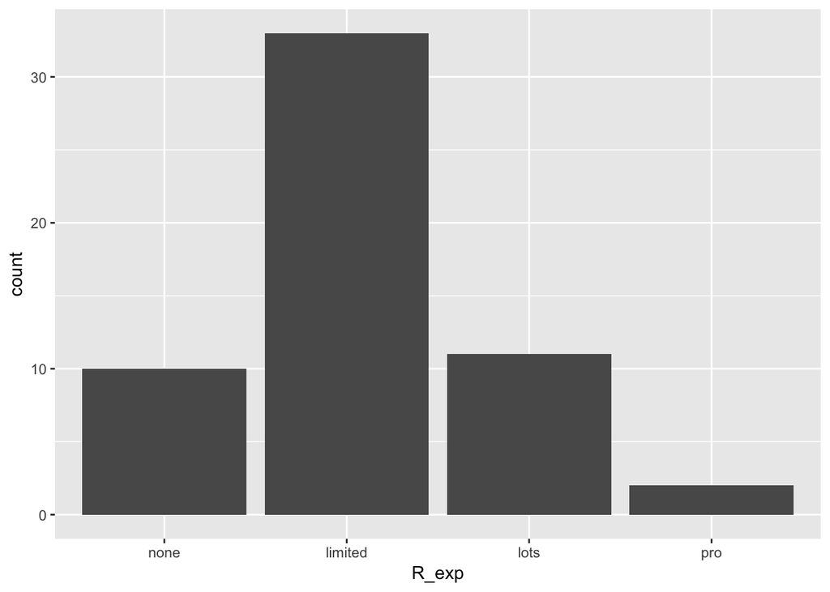

Distribution of prior R experience

```r
R_exp_hist <- survey %>%
  ggplot() +
  aes(x=R_exp) +
  geom_histogram(stat = "count") # R_exp is discrete
R_exp_hist
```

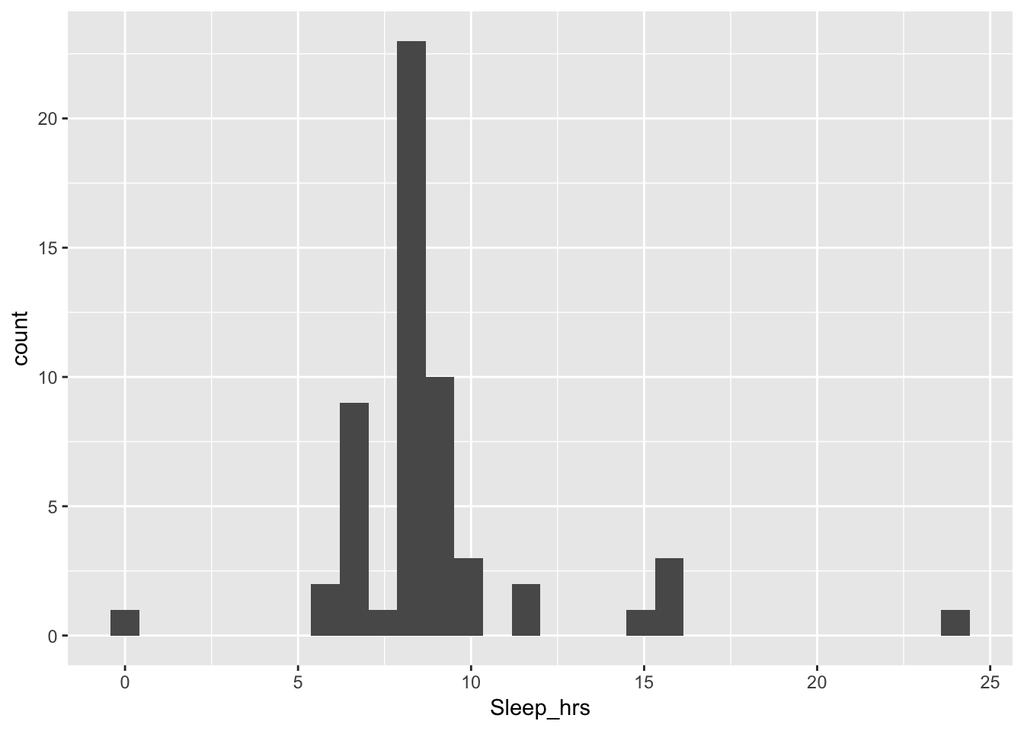

Distribution of preferred sleep hrs/day

```r
Sleep_hrs_hist <- survey %>%
  ggplot() +
  aes(x=Sleep_hrs) +
  geom_histogram() # Sleep_hrs is continuous
Sleep_hrs_hist
```

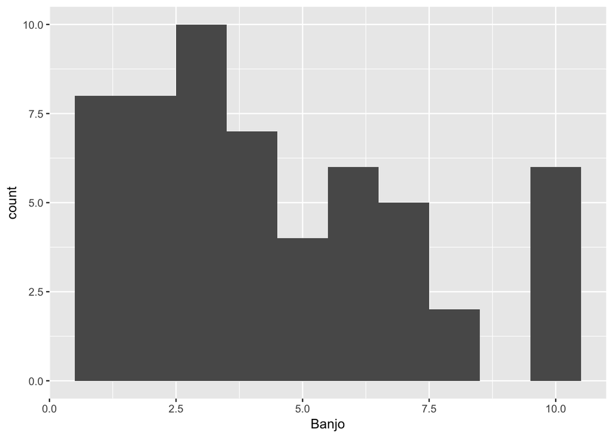

Distribution of Enthusiasm for Banjo Music

```r
Banjo_hist <- survey %>%
  ggplot() +
  aes(x=Banjo) +
  geom_histogram(bins = 10)
Banjo_hist
```

Does R experience have any relation to banjo music enthusiasm or one’s psychological age?

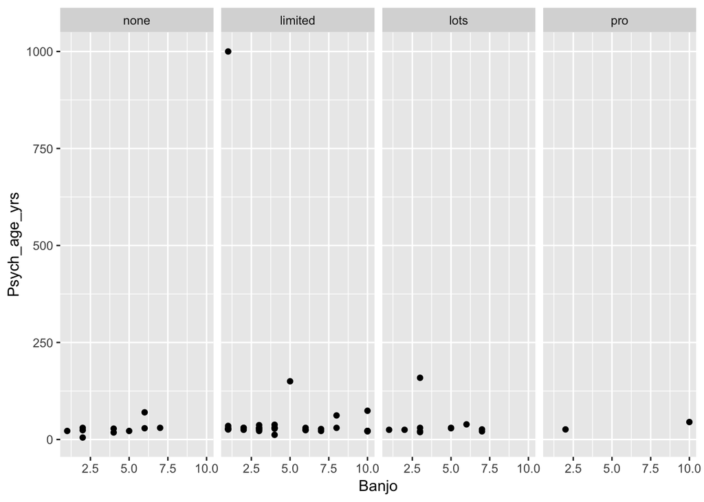

```r
Banjo_vs_r_exp <- survey %>%
  ggplot() +
  aes(x=Banjo, y=Psych_age_yrs) +
  facet_grid(. ~ R_exp) +
  geom_point()
  # + stat_smooth()
Banjo_vs_r_exp
```

[figure not shown]

```r
crisis_plot <- survey %>%
  ggplot() +
  aes(x=Crisis) +
  geom_bar()
crisis_plot
```

# Data documentation (codebook)

Every data set should be documented. You can generate a template data codebook with some useful summary information using the package `dataMaid`.

```r
if(!require(dataMaid)){install.packages('dataMaid')}
library(dataMaid)
dataMaid::makeCodebook(data = survey,
                       reportTitle = 'Codebook for 2018 R bootcamp survey',
                       replace = TRUE)
```

```
## Data report generation is finished. Please wait while your output file is being rendered.
```

Then, we can look at the `codebook_survey.Rmd` file and edit it as needed, especially the section with the code descriptions.

[output not shown]

# Analysis

I could use a document like this to plan out my analysis plan **before** I conduct it. If I used simulated data, I could make sure that my workflow will run when I get real (cleaned) data. I could even preregister my analysis plan before I conduct it. That doesn’t preclude later exploratory analyses, but it does hold me and my collaborators accountable for what I predicted in advance.

# Notes

Notice that I sometimes put a label like `Banjo-vs-r-exp` in the brackets `{}`for a given ‘chunk’ of R code. The main reasons to do this are:

- It sometimes makes it easier to debug your code.
- In some cases, you can have this ‘chunk’ name serve as the file name for a figure you generate within a chunk.
- In a bit, we’ll see how these chunk names are useful for making tables, figures, and equations that generate their own numbers.